# CH3/40220

28/02/2022

## Course Timetable

- Week 1: In Person - Intro to the course, refresher course on thermodynamics
- Week 2: LOIL - Lecture - Crown & lariat ethers and related molecules
- Week 3: In Person - Workshop (research paper based exercise)
- Week 4: LOIL - Lecture - Self assembly the basics, DNA duplexing and beyond
- Week 5: In Person - Workshop (research paper based exercise)
- Week 6: LOIL - Lecture - Tertiary structures
- Week 7: In Person - Workshop (research paper based exercise)
- Week 8: LOIL - Lecture - Binding of small molecules to biopolymers
- Week 9: In Person - Workshop (research paper based exercise)
- Week 10: LOIL - Lecture - Solvation, hydrodynamics & osmosis
- Week 11: In Person - Workshop example exam questions

## DNA bases

DNA is (usually) composed of four different heterocyclic bases:

- the purines:

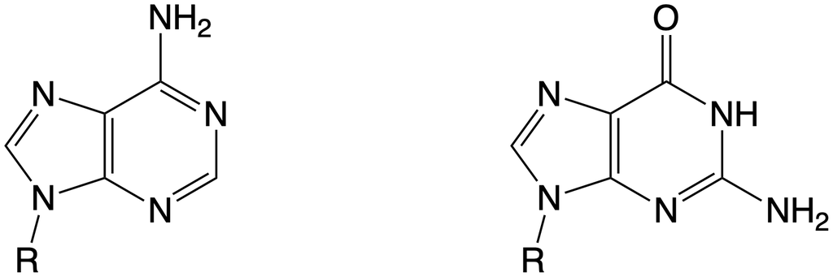

- the pyrimidines

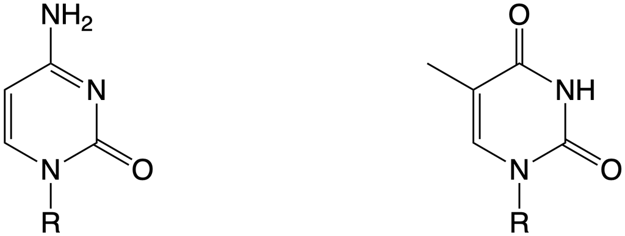

The pyrimidine bases of DNA: cytosine (C) left and thymine (T), right.

bound to a sugar and phosphate group (R).

## Nucleotides

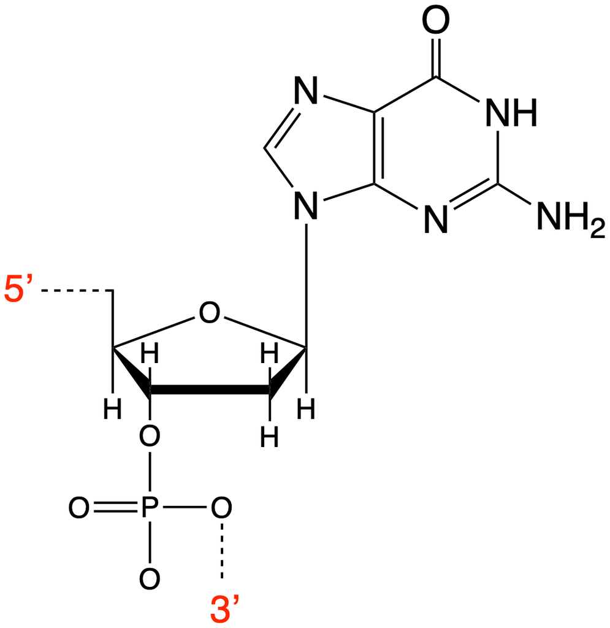

The purine base guanosine bound to the deoxyribose sugar and phosphate, the polymer is a repeat of the unit with a bond connecting the dashed lines

Polymer DNA is formed by polymerisation along the sugar phosphate backbone (phosphodiester bonds).

The DNA has ‘direction’ due to this asymmetry of the sugar phosphate backbone.

## GC Base Pairing

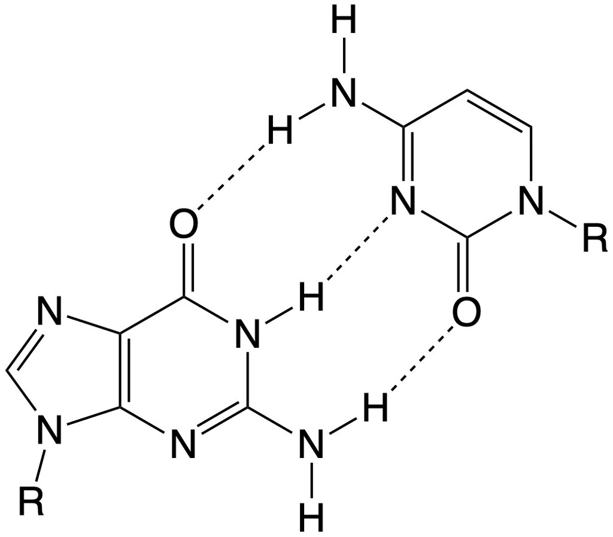

The base pairing between guanine and cytosine with three hydrogen bonds. Note one of the bases is flipped over, due to the two strands running antiparallel.

## AT Base Pairing

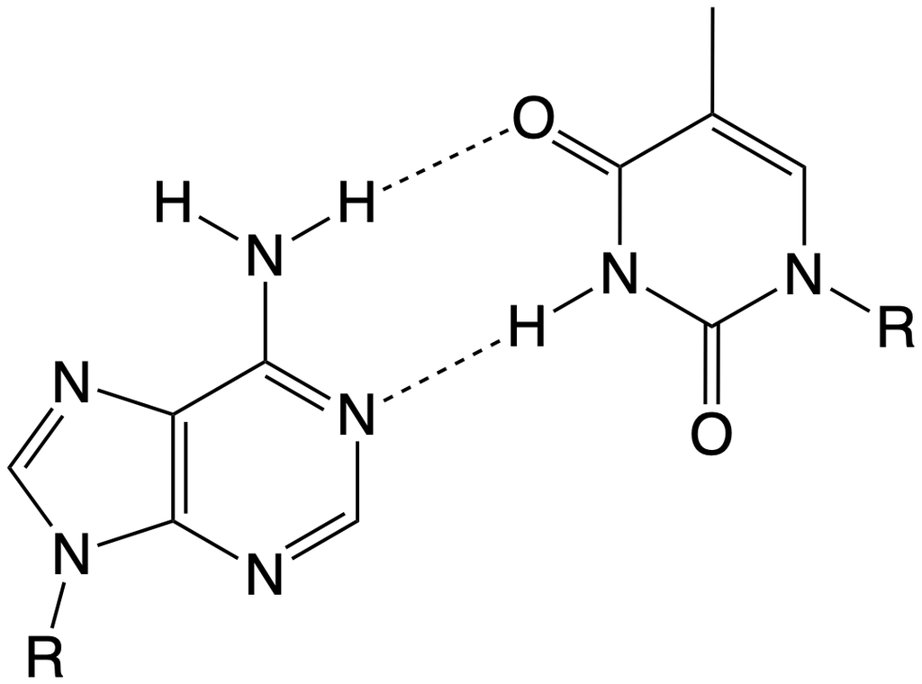

The base pairing between adenine and thymine with just two hydrogen bonds. Note one of the bases is flipped over, due to the two strands running antiparallel.

## DNA duplexing

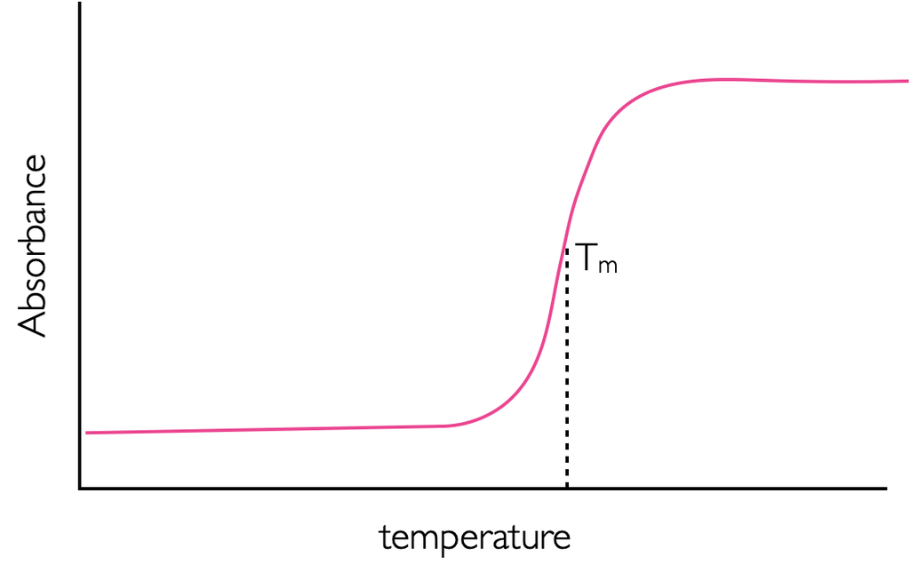

As the temperature increases the absorbance of a sample of DNA also increaes, this is due to melting of the DNA duplex, and loss of quadrupole π interactions between the stacked base pairs.

We know that there is a temperature dependence of absorption when a solution of DNA is heated.

The melting temperature T<sub>m</sub> is the temperature ‘halfway between the turning points’.

[Forces in the DNA duplex](http://libproxy.bath.ac.uk/login?url=https://www.ncbi.nlm.nih.gov/pmc/articles/PMC7351851/)

## Factors affecting duplex melting temperature

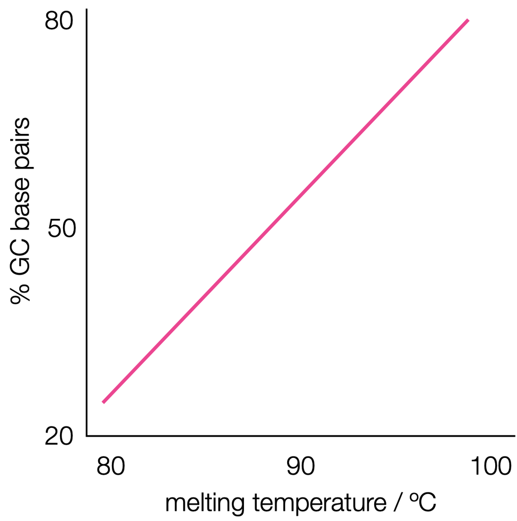

The melting temperature of polymer DNA increases with increasing GC base pair proportion.

The length of the polymer also affects the melting temperature, the longer the polymer the higher the melting temperature.

Salt concentration (cation) also affects the melting temperature as it reduces the columbic interactions between the negatively charged phosphate backbone.

[Enthalpy and entropy in DNA melting](https://www.jbc.org/action/showPdf?pii=S0021-9258%2818%2983065-4)

## Melting and cooling

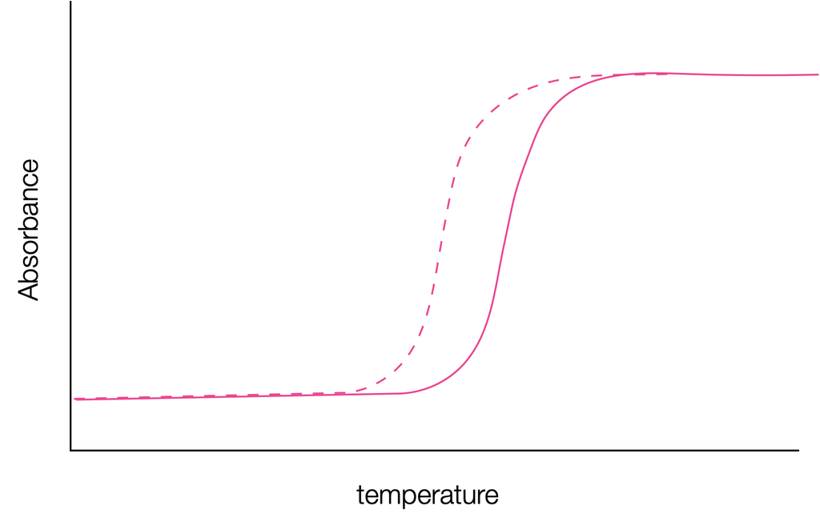

Heating and cooling of DNA duplex samples shows hysterisis due to kinetic factors.

Unless samples are cooled very slowly they will not anneal.

Only ‘oligomer’ short strands will anneal.

## DNA duplexing

However the ‘melting temperature’ is not just a property of the number of hydrogen bonds between base pairs.

For example the melting temperature of poly(dA)・poly(dT) is higher than poly[d(AT)]・poly[d(TA)].

The stability of DNA duplexing is down to both the base pairs & the base sequence.

[Predicting DNA duplex stability from the base sequence](http://libproxy.bath.ac.uk/login?url=https://www.pnas.org/doi/pdf/10.1073/pnas.83.11.3746)

## Sequence specific effects

| Interaction | −ΔH / kJ mol\(^{-1}\) | −ΔS / kJ K\(^{-1}\) mol\(^{-1}\) | −ΔG / kJ mol\(^{-1}\) |
| --- | --- | --- | --- |
| AA/TT | 38 | 100.4 | 7.9 |
| AT/TA | 36 | 100.0 | 6.3 |
| TA/AT | 25 | 71.7 | 3.8 |
| CA/GT | 24 | 54.0 | 7.9 |
| GT/CA | 27 | 72.4 | 5.4 |
| CT/GA | 33 | 87.0 | 6.7 |
| GA/CT | 23 | 56.4 | 6.7 |
| CG/GC | 49.8 | 116.3 | 15.1 |
| GC/CG | 46.4 | 111.7 | 13.0 |
| GG/CC | 46.0 | 111.3 | 13.0 |

Data from: [Predicting DNA duplex stability from the base sequence](http://libproxy.bath.ac.uk/login?url=https://www.pnas.org/doi/pdf/10.1073/pnas.83.11.3746)

## Sequence specific effects on the enthalpy of duplexing

The enthalpy of hybridisation is given by:

\(\Delta H_{\textrm{total}}= \Delta h_i + \sum_x \Delta h_x\)

where

- \(\Delta h_i\) is the initiation enthalpy (which can reasonably be assumed to be zero)
- \(\Delta h_x\) is the contribution from each of the base sequence combinations

## Sequence specific effects on the free energy of duplexing

A similar process can be used to determine the free energy of duplexing

\(\Delta G_{\textrm{total}}= -(\Delta g_i+ \Delta g_{\textrm{sym}}) + \sum_x \Delta g_x\)

in this case the helix initiation free energy (\(\Delta g_i\)) can be assumed to be around 20 kJ mol<sup>-1</sup> for duplexes containing GC and 24 kJ mol<sup>-1</sup> for sequences exclusively containing AT base pairs.

The term \(\Delta g_{\textrm{sym}}\) is 1.6 kJ mol<sup>-1</sup> for ‘self complementary’ sequences and 0 otherwise.

## PCR

The polymerase chain reaction uses a number of thermodynamic ‘melt - anneal’ cycles.

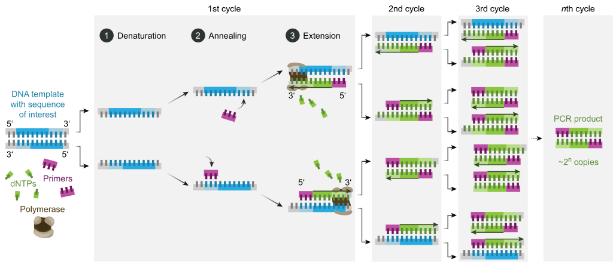

DNA is denatured by heating to high temperatures (95 ºC) to melt the DNA, rapid cooling to 55 ºC where primers bind to complementary sequences, followed by heating to 72 ºC where the polymerase catalyses formation of strands.

Enzoklop, CC BY-SA 4.0 https://creativecommons.org/licenses/by-sa/4.0, via Wikimedia Commons

## Primary, Secondary & Tertiary Structure

- **Primary** the ‘sequence’ of the DNA bases along the strand
- **Secondary** the duplexing (or otherwise) - so duplex, quadruplex
- **Tertiary** the overall ‘shape’ of the DNA - the ‘double helix’
- **Quaternary** how these tertiary structures can be built together

## Tertiary structures

The ‘classic’ DNA is ‘B-form’

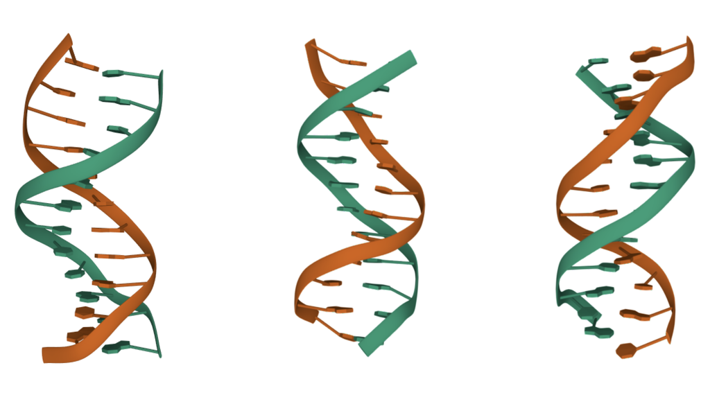

The tertiary structure of B-form DNA showing the major and minor groove.

Bases are separated by the *van der Waals distance* of 3.32 Å, and the double helix is about 23.7 Å in diameter. One complet turn is completed in just over 10 base pairs.

## Tertiary structures

There are other *cellular* DNA forms that can occur.

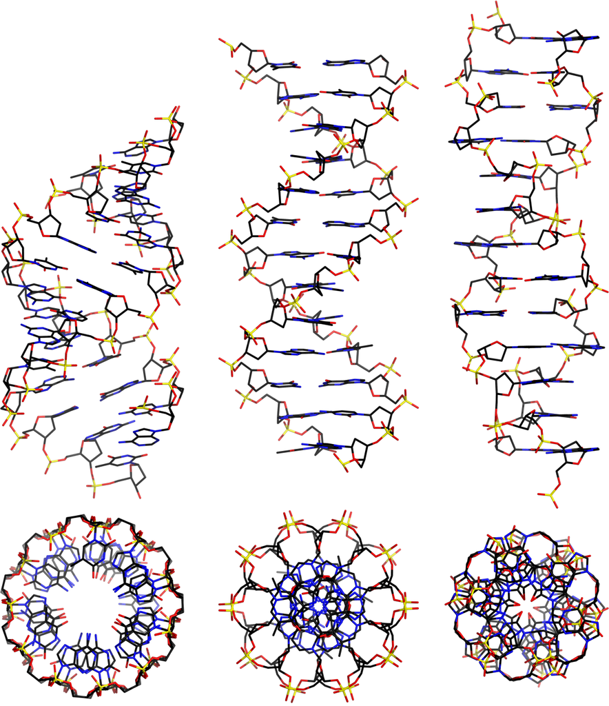

A-(left), B-(centre) and Z-(right) form DNA, each a duplex*.

A- & B- form DNA are both right handed helicies, and Z-form a left handed helix.

Each have the same base pair interactions

*Mauroesguerroto, CC BY-SA 4.0 https://creativecommons.org/licenses/by-sa/4.0, via Wikimedia Commons

## Molecular meccano

[Review article Supramolecular DNA structures](https://pubs-rsc-org.ezproxy1.bath.ac.uk/en/content/articlepdf/2011/cs/c1cs15253j)

*Fiona to attempt some bad sketching*

## The Workshop

We are going to look at some of the thermodynamics of duplexing

[DNA nearest neighbour thermodynamics](http://libproxy.bath.ac.uk/login?url=https://www.pnas.org/doi/full/10.1073/pnas.95.4.1460)

Please take a ‘quick read’ of this whole paper before the workshop.